# assign4

```r
cat("
<style>
h2 {
  font-size: 24px;
  color:#045a8d;
  text-align:center;
}

h3 {
  font-size: 10px;
  color:#2b8cbe;
  text-align:center;
}

h4 {
  font-size: 14px;
  color:#2b8cbe;
}
</style>
")
```

## 1.

[output not shown]

So, let’s assume that the researcher has **15** patients with an average starting CD4+ cell count of **350**. She starts these patients on her new treatment, and after a month, she finds that the average count has increased to **365** with a standard deviation of **35**.

### a.

#### Specify the null and alternative hypotheses for the treatment.

Null = treatment has no effect on average count Alternative = treatment has an effect on average count

### b.

#### Test the null hypothesis with the appropriate test statistic. Interpret the results.

Difference between means = t-test

```r
t_score = (365-350)/(35/sqrt(15))
(p_val = 2 * pt(−t_score, df=15-1))
```

```
## [1] 0.1191687
```

The pvalue is 0.119, which is above the threshold of 0.05. Therefore, these results are likely to have happened by chance

### c.

#### Find the minimum number of patients the researcher would need for her study in order to be able to reject the null hypothesis at the .05 level, if the average count increase and standard deviation stayed the same.

```r
# 1.96 = (365-350)/(35/sqrt(n))
# 1.96 = (365-350)*sqrt(n)/(35)
# sqrt(n) = 1.96*35/(365-350)
n = (2.07*35/(365-350))^2
n = ceiling(n)
n
```

```
## [1] 24
```

```r
# testing
# t_score = (365-350)/(35/sqrt(n))
# (p_val = 2 * pt(−t_score, df=n-1))
```

Need a sample size of 24 (round up)

## 2.

```
Using the POL201 data set, let’s examine the relationship between gender and political party affiliation.
```

### a.

#### Specify null and alternative hypotheses for how gender might relate to party affiliation. Describe why you think this is the case. That is, explain why you put forward these specific hypotheses.

- Null: Gender does not play a role in party affiliation
- Alternate: Gender does play a role in party affiliation

### b.

#### Create a table with the margins showing the relationship between gender and party affiliation. Interpret the results.

```r
POL201=read.csv("http://www.sfu.ca/~sweldon/POL201.csv")

addmargins(table(POL201$gender, POL201$party))
```

```
##
##          Conservative Liberal NDP None Sum
##   Female            1      15  17   10  43
##   Male              9       5   9   10  33
##   Sum              10      20  26   20  76
```

### c.

#### Test this relationship with the appropriate test statistics. Interpret the results.

- Use chi squared test

```r
chisq.test(POL201$gender, POL201$party)
```

```
##
##  Pearson's Chi-squared test
##
## data:  POL201$gender and POL201$party
## X-squared = 12.767, df = 3, p-value = 0.005169
```

Pvalue is below 0.05 cutoff for signifigance. Therefore, there is a relationship between gender and political affiliation

## 3.

[output not shown]

### a.

#### Develop null and alternative hypotheses for the expected relationship between the reported random number generated and guess at the percentage of countries in Africa that are in the world. Explain why you offer these specific hypotheses.

- Null: There is no relationship between the reported random number and the guessed percentage
- Alternate: There is a relationship between the reported random number and the guessed percentage

### b.

#### Create a side-by-side boxplot for the estimate of the percentage of countries in the world that were in Africa by the random number prompt (the variable name is survey and it is the first one in the entire data set).

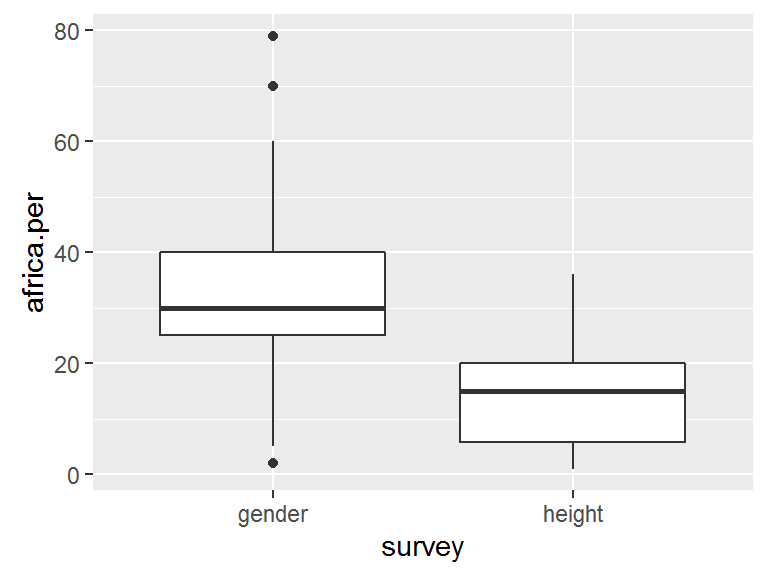

```r
ggplot(POL201, aes(survey, africa.per)) +
  geom_boxplot()
```

### c.

#### Interpret the results. That is what does the side-by-side boxplot show for each variable? What do the results suggest about the relationship between number prompting and the reported estimates? And, possibly about human cognition more generally?

People are influenced by the “random number”, such that people who saw the higher number were “primed” to think around that range.

### d.

#### Test this relationship with the appropriate test statistic. Interpret the results.

```r
t.test(africa.per ~ survey, POL201)
```

```
##
##  Welch Two Sample t-test
##
## data:  africa.per by survey
## t = 5.6623, df = 56.54, p-value = 5.214e-07
## alternative hypothesis: true difference in means is not equal to 0
## 95 percent confidence interval:
##  11.82796 24.77461
## sample estimates:
## mean in group gender mean in group height
##             32.75000             14.44872
```

P value is < 0.05, which means there is a statistically significant difference between the guesses of african countries across the two randomly generated numbers

### e.

#### How are side-by-side boxplots and t-tests related to one another? What are the advantages of each for understanding the relationship between two variables?

side-by-side boxplots are a good way of visualizing the spread of the data. If the boxplots show drastically different distributions (difference in the 25th and 75th quartiles), then the t-test will likely show a statistical significance.

### f.

#### Finally, run a bivariate linear regression of percentage of states in Africa (dependent variable) on survey version (independent variable). Looking at the output of the linear regression, compare it with the results from the t-test. What are the similarities?

```r
summary(lm(africa.per ~ survey, POL201))
```

```
##
## Call:
## lm(formula = africa.per ~ survey, data = POL201)
##
## Residuals:
##     Min      1Q  Median      3Q     Max
## -30.750  -7.750  -0.449   7.250  46.250
##
## Coefficients:
##              Estimate Std. Error t value Pr(>|t|)
## (Intercept)    32.750      2.284  14.341  < 2e-16 ***
## surveyheight  -18.301      3.209  -5.703  2.2e-07 ***
## ---
## Signif. codes:  0 '***' 0.001 '**' 0.01 '*' 0.05 '.' 0.1 ' ' 1
##
## Residual standard error: 14.08 on 75 degrees of freedom
##   (3 observations deleted due to missingness)
## Multiple R-squared:  0.3025, Adjusted R-squared:  0.2932
## F-statistic: 32.53 on 1 and 75 DF,  p-value: 2.203e-07
```

The pvalue for the survey variable is similar to the pvalue from the t-test

## 4.

```
Using the Countries data set, let’s examine the relationship between the level of freedom in a country (fh) and reported happiness levels (happy).
```

### a.

#### Specify null and alternative hypotheses for how level of freedom might relate to happiness. Be sure to explain why you put forward your specific hypotheses.

- Null: The happiness level of countries with different freedom levels are equal
- Alternate: The happiness level of countries with different freedom levels are not equal

Want to understand how a country’s freedom level influences happiness, if at all

### b.

#### Create a side-by-side boxplot for the estimate of the levels of happiness in a country by the level of freedom.

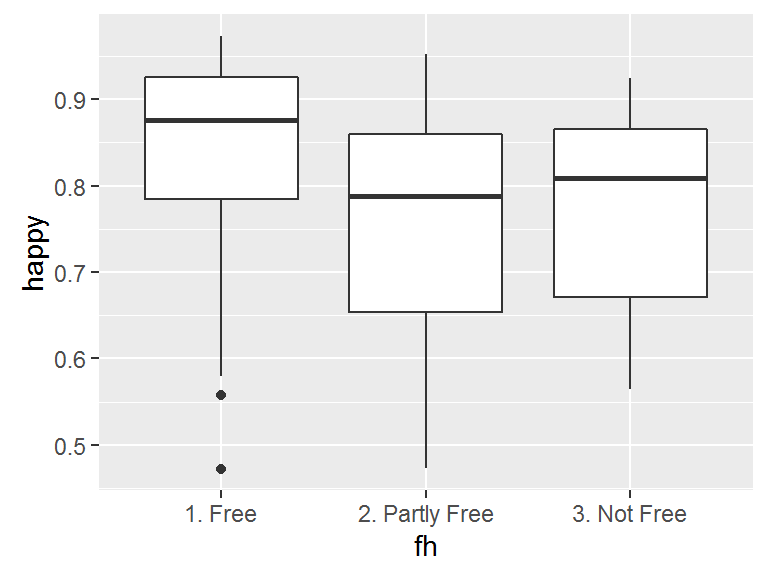

```r
Countries=read.csv("http://www.sfu.ca/~sweldon/Countries.csv")

ggplot(Countries, aes(fh, happy)) +
  geom_boxplot()
```

### c.

#### Interpret the results. That is what does the side-by-side boxplot show for each variable?

The results show that free countries are generally more happy than partly free and not free countries. The happiness level between partly and not free countries are roughly the same

### d.

#### Test this relationship with the appropriate test statistic. Interpret the results.

- Use anova

```r
anova(aov(formula = happy ~ fh, data = Countries))
```

```
## Analysis of Variance Table
##
## Response: happy
##           Df  Sum Sq  Mean Sq F value Pr(>F)
## fh         2 0.14311 0.071554  4.5487 0.0131 *
## Residuals 91 1.43149 0.015731
## ---
## Signif. codes:  0 '***' 0.001 '**' 0.01 '*' 0.05 '.' 0.1 ' ' 1
```

## 5.

Using the Countries data set:

### a.

#### Calculate the mean, median, standard deviation, and range for the level of protest in a country for just those countries that are in Sub-Saharan Africa.

```r
africans <- readLines(con = textConnection("Angola
Benin
Botswana
Burundi
Cameroon
Cape Verde
Central African Republic
Chad
Comoros
Congo
Congo, Democratic Republic
Equatorial Guinea
Eritrea
Ethiopia
Gabon
Gambia
Ghana
Guinea
Kenya
Lesotho
Liberia
Madagascar
Malawi
Mali
Mauritania
Mauritius
Mozambique
Namibia
Niger
Nigeria
Rwanda
Sao Tome and Principe
Senegal
Seychelles
Sierra Leone
Somalia
South Africa
Sudan
Swaziland
Togo
Uganda
Zambia"))

african_countries <- subset(Countries, country %in% africans)

summary(african_countries$protest)
```

```
##    Min. 1st Qu.  Median    Mean 3rd Qu.    Max.    NA's
##  0.4838  0.5120  0.5402  0.5529  0.5875  0.6348      39
```

```r
sd(african_countries$protest, na.rm = TRUE)
```

```
## [1] 0.07627865
```

### b.

#### Calculate the mean, median, standard deviation, and range for the level of protest in a country for just those countries that have a gini index greater than 30.

```r
gini_countries = subset(Countries, gini > 30)
summary(gini_countries$protest)
```

```
##    Min. 1st Qu.  Median    Mean 3rd Qu.    Max.    NA's
## 0.08197 0.34770 0.49780 0.61540 0.77620 1.41600      50
```

```r
sd(gini_countries$protest, na.rm = T)
```

```
## [1] 0.3676268
```

### c.

#### Fit a linear model to level of protest (dependent variable) & reported happiness level (independent variable) for just those countries that are free based on the fh variable.

*[Hint: Be sure to look specifically at the labels in fh for the levels of freedom]*

```r
free_countries = subset(Countries, fh == "1. Free")
lm(protest ~ happy, free_countries)
```

```
##
## Call:
## lm(formula = protest ~ happy, data = free_countries)
##
## Coefficients:
## (Intercept)        happy
##      -0.787        1.923
```

### i.

#### Create a scatter plot with a linear regression line added for the above relationship.

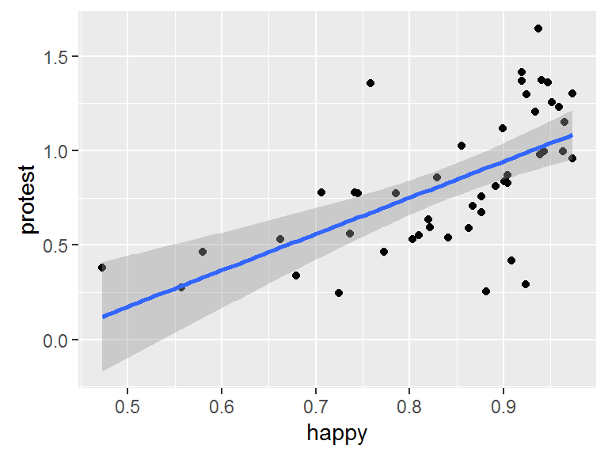

```r
ggplot(free_countries, aes(happy, protest)) + geom_point() + geom_smooth(method = "lm")
```

### d.

#### Fit a linear model to level of protest (dependent variable) & reported happiness level (independent variable) for just those countries with a GDP per capita greater than $15,000.

```r
rich_countries = subset(Countries, gdp > 15000)
lm(protest ~ happy, rich_countries)
```

```
##
## Call:
## lm(formula = protest ~ happy, data = rich_countries)
##
## Coefficients:
## (Intercept)        happy
##      -1.073        2.350
```

### i.

#### Create a scatter plot and add a linear regression line for this relationship.

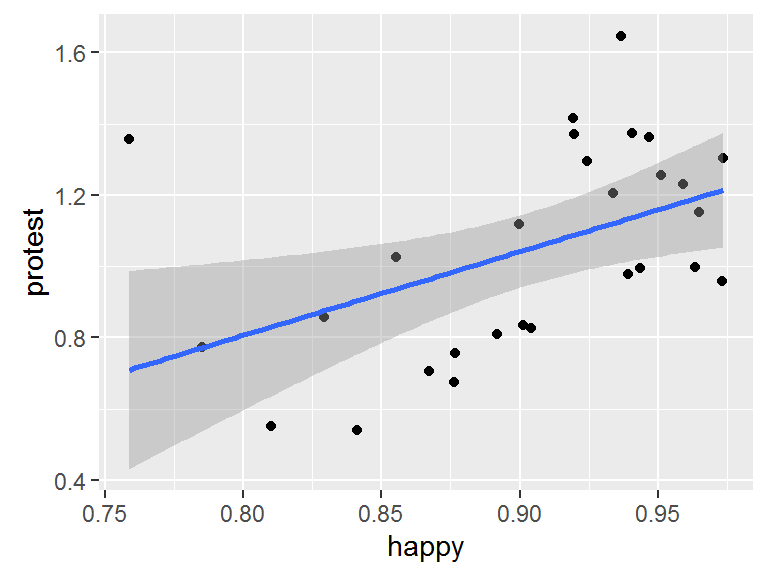

```r
ggplot(rich_countries, aes(happy, protest)) + geom_point() + geom_smooth(method = "lm")
```